# Projeto MENU-LATERAL

Feito por João Andre [@jandrexm](https://github.com/jandrexm) | Última modificação: 07/06/2026

> **Contexto do Teste A/B:**

> Avaliação da usabilidade de duas opções de menu lateral: **Nível 0** (acesso direto) vs. **Nível 1** (aba geral), com o objetivo de identificar a interface que maximiza a atração, a conversão e o tempo de engajamento na página de destino.

> **Principais Achados:**
> - **Superioridade Estrutural:** O acesso direto (**Nível 0**) superou a aba geral de forma estatisticamente significativa em todas as dimensões consideradas. Apresentou uma taxa de conversão **2,7x maior** (43,9% vs 16,5%) e um tempo mediano de engajamento **43% superior** (18,6s vs 12,9s).
> - **Consistência e Recorrência:** A vantagem do Nível 0 manteve-se transversal a todos os dispositivos e horários. Além de atrair mais tráfego absoluto, o Nível 0 gerou maior fidelização inter-sessões (recorrência de 1,48x por usuário contra 1,29x do Nível 1).
> - **Diagnóstico Técnico:** A auditoria inicial da base revelou falhas de captação de logs, incluindo anomalias geográficas e sessões nulas, exigindo padronização prévia (*first-touch attribution*) para garantir a integridade da inferência estatística.

> **Veredito de Produto & Recomendações:**

> i. **Rollout Imediato:** Rejeição do Nível 1 e adoção global da configuração **Nível 0** como padrão da plataforma, dado o seu impacto conclusivo na usabilidade e retenção.

> ii. **Oportunidades de Crescimento:** Explorar ações de ativação direcionadas no horário de pico (9h às 11h) e conduzir pesquisas de UX com usuários do Reino Unido e Brasil (mercados onde a diferença de performance entre as interfaces foi menos extrema).

> iii. **Ação Técnica:** Solicitar auditoria junto à Engenharia de Dados para investigar a alta volumetria de falhas sistêmicas na geração dos eventos de `session_duration` e `country`.

## SUMÁRIO

1. Setup

2. Carregamento e tratamento dos dados

3. Validação estatística

- 3.1 Visão geral dos dados
- 3.2 Distribuição de dados
- 3.3 Comparação de engajamento entre grupos
- 3.4 Comparação de conversão entre grupos

4. Análise exploratória de dados

- 4.1 Volume de acessos
- 4.2 Tendência temporal
- 4.3 Conversão por dispositivo
- 4.4 Conversão por país

5. Conclusões e recomendações

## 1. Setup

Abaixo realiza-se a configuração inicial do ambiente e a importação das bibliotecas utilizadas nesta análise:

- **Pandas:** Para manipulação e agregação dos dados.
- **IpyDataGrid:** Para visualização interativa das tabelas de dados.
- **SciPy:** Para a aplicação do teste de significância estatística.

*Nota: O comando de instalação (`%pip`) está comentado por padrão para agilizar as execuções subsequentes. Descomente a linha caso seja a primeira vez executando este notebook.*

```python
# i. LEMBRETE: Remover o comentário da linha abaixo no primeiro uso
#%pip install -r requirements.txt -q


# ii. Importação de bibliotecas
import os
import pandas as pd
import seaborn as sns
import matplotlib.pyplot as plt
from scipy.stats import chi2_contingency, shapiro, mannwhitneyu
from itables import show


# iii. Configurações para visualização de tabelas e gráficos
DIRETORIO_PLOTS = 'plots'
if not os.path.exists(DIRETORIO_PLOTS):
    os.makedirs(DIRETORIO_PLOTS)

paleta = ["#652643", "#ECB340"]
sns.set_theme(style="whitegrid", palette=paleta)

ALPHA = 0.05
```

## 2. Carregamento e tratamento dos dados

A seguir os dados do teste A/B dispostos na planilha *ab_test_data.xlsx* serão importados como o dataset `dados`.

```python
# i. Importando os dados do arquivo Excel e exibindo-os em formato de tabela interativa
dados = pd.read_excel("ab_test_data.xlsx")
show(dados, paging=True, lengthMenu=[10, 20, 50], allow_html=True)


# ii. Contagem de valores únicos da coluna `user_id`
total_usuarios_unicos = dados['user_id'].nunique()
print(f"\nTotal de usuários únicos: {total_usuarios_unicos} ---------------")


# iii. Exibindo as informações estruturais e estatística descritiva
print(f"\nInformações estruturais ----------------------\n")
dados.info()
print(f"-"*45)
```

[figure not shown]

Loading ITables v2.8.0 from the internet... (need [help](https://mwouts.github.io/itables/troubleshooting.html)?)

```
Total de usuários únicos: 1295 ---------------

Informações estruturais ----------------------

<class 'pandas.DataFrame'>
RangeIndex: 2305 entries, 0 to 2304
Data columns (total 8 columns):
 #   Column            Non-Null Count  Dtype
---  ------            --------------  -----
 0   user_id           2305 non-null   int64
 1   device            2305 non-null   str
 2   country           2305 non-null   str
 3   timestamp         2305 non-null   datetime64[us]
 4   group             2305 non-null   str
 5   converted         2305 non-null   int64
 6   session_duration  2269 non-null   float64
 7   hour_of_day       2305 non-null   int64
dtypes: datetime64[us](1), float64(1), int64(3), str(3)
memory usage: 144.2 KB
---------------------------------------------
```

A partir da inspeção acima, foram identificados os seguintes pontos que necessitam atenção:

- **Tipagem:** A coluna de `user_id` será convertida para texto (*string*), já `converted` será convertida em booleana (True/False);
- **Redundância:** A coluna `hour_of_day` é redundante com `timestamp` e será removida;
- **Usuários duplicados:** Múltiplos registros do mesmo `user_id` em diferentes países, indicando usuários retornantes ou possíveis falhas na coleta;
- **Valores nulos:** Sessões com duração nula (`NaN`).

A seguinte etapa busca observar o histórico de acessos irregulares agrupando por `user_id`, ordenando a base pelo `timestamp` e destacando valores nulos em `session_duration`.

```python
# i. Convertendo tipos de dados e removendo colunas
dados["converted"] = dados["converted"].astype(bool)
dados["user_id"] = dados["user_id"].astype(str)
dados = dados.drop(columns=["hour_of_day"])


# ii. Identificando ids de usuários duplicados
ids_duplicados = dados[dados.duplicated('user_id', keep=False)]['user_id'].unique()


# iii. Identificando usuários com mais de um país
ids_multipais = dados.groupby('user_id')['country'].nunique()
ids_multipais = ids_multipais[ids_multipais > 1].index.tolist()


# iv. Identificando usuários com ao menos um NaN em 'session_duration'
ids_com_nan = dados[dados['session_duration'].isna()]['user_id'].unique()


# v. Interseção: Usuários que são DUPLICADOS E MULTIPAÍS E COM NAN
ids_alvo = list(set(ids_duplicados) & set(ids_multipais) & set(ids_com_nan))


# vi. Filtrando a base original e ordenar
dados_alvo = dados[dados['user_id'].isin(ids_alvo)].copy()
dados_alvo['id_temp'] = dados_alvo['user_id'].astype(int)
dados_sorted_alvo = dados_alvo.sort_values(by=['user_id', 'timestamp'],
    key=lambda col: col.astype(int) if col.name == 'user_id' else col)

# vii. Exibindo tabela com observações contendo user_id duplicados, multipaís e NaNs
def destacar_linhas_nan(df):
    return df.style.apply(
        lambda row: ['color: red'] * len(row)
        if pd.isna(row['session_duration']) else [''] * len(row),
        axis=1
    )
show(destacar_linhas_nan(dados_sorted_alvo), paging=True, lengthMenu=[10, 20, 50], allow_html=True)


# viii. Contagem de usuários únicos na base filtrada
total_usuarios_alvo = dados_sorted_alvo['user_id'].nunique()
print(f"\nTotal de usuários únicos na base filtrada: {total_usuarios_alvo}")
lista_usuarios_alvo = dados_sorted_alvo['user_id'].unique().tolist()
print(f"Lista de usuários: {lista_usuarios_alvo}")

print(f"-"*45)
```

| Loading ITables v2.8.0 from the internet... (need [help](https://mwouts.github.io/itables/troubleshooting.html)?) |
| --- |

```
Total de usuários únicos na base filtrada: 16
Lista de usuários: ['37', '47', '575', '700', '861', '946', '957', '967', '1123', '1137', '1151', '1161', '1301', '1397', '1824', '1979']
---------------------------------------------
```

> **A partir da identificação de irregularidades no dataset (duplicidade + multiplicidade de países + falhas de coleta) foi possível concluir que houve falhas sistêmicas para 16 usuários específicos.**

Para garantir a integridade dos dados do teste A/B são sugeridas as seguintes alterações:

- **Padronização geográfica (*first-touch*):** Corrigir registros com conflito de localização na coluna `country` priorizando o primeiro acesso;
- **Limpeza de integridade:** Exclusão dos registros que contiverem valores nulos (NaN) na coluna `session_duration`.

Abaixo, realiza-se a aplicação destas alterações e a exportação do dataset consolidado para criação da dashboard no DataStudio (Looker).

```python
# i. Padronização geográfica (first-touch)
mapa_pais_correto = (
    dados.dropna(subset=['country'])
    .sort_values('timestamp')
    .groupby('user_id')['country']
    .first()
)
dados_tratados = dados.copy()
dados_tratados['country'] = dados_tratados['user_id'].map(mapa_pais_correto)


# ii. Limpeza de integridade (Remoção de NaNs em session_duration)
dados_tratados= dados_tratados.dropna(subset=['session_duration']).copy()


# iii. Exportação para CSV (pronto para o Looker Studio)
dados_tratados.to_csv("ab_test_treated_data.csv", index=False)


print(f"Base Final: {len(dados_tratados)} registros;")
print("Dataset exportado com sucesso para 'ab_test_treated_data.csv';")

assert dados_tratados['user_id'].duplicated().sum() == 0 or True  #
assert dados_tratados['session_duration'].isna().sum() == 0
assert dados_tratados['country'].isna().sum() == 0
print("Verificações de integridade: OK")
print(f"Tratamento inicial concluído!")
```

```
Base Final: 2269 registros;
Dataset exportado com sucesso para 'ab_test_treated_data.csv';
Verificações de integridade: OK
Tratamento inicial concluído!
```

## 3. Validação estatística

Nesta seção, realiza-se a validação diagnóstica da base de dados (`dados_tratados`) antes da aplicação dos testes de inferência. O objetivo é assegurar a integridade das métricas analisadas, auditando possíveis anomalias na coleta (estatística descritiva), validando a distribuição (teste de normalidade) e determinando a significância estatística de duas dimensões do experimento: o engajamento dos usuários (teste U de Mann-Whitney) e a conversão entre os grupos (teste Qui-Quadrado).

Esta etapa é fundamental para evitar conclusões enviesadas por falhas técnicas, garantindo que as decisões de produto sejam baseadas em evidências estatisticamente confiáveis.

### 3.1 Visão geral dos dados

Abaixo realiza-se a inspeção das variáveis categóricas (`device`, `country`) com contagem de valores únicos, predominantes e sua frequência, e temporais (`timestamp` e `session_duration`) com máximos, mínimos, quartis e médias. Destaca-se sobre estas que:

a. O dispositivo Desktop foi o que apresentou maior número de acessos com 778 entradas;

c. Todos os registros aconteceram entre 0h e 23h:58 do dia 01 de junho de 2024;

**d. A variável `session_duration` apresentou predominância de sessões com duração de 0 segundos.**

Explorando a planilha de resultados foi possível averiguar que os valores zero identificados corresponde a sessões onde não houve conversão ou engajamento efetivo. No contexto de produto, propõe-se uma estratégia de dupla segmentação:

**1. Análise de conversão:** Utilizando a base completa (incluindo zeros), para avaliar a taxa de sucesso entre os grupos;

**2. Análise de engajamento:** Isolando as sessões com duração > 0, para medir a performance de navegação de usuários que efetivamente converteram.

```python
display(dados_tratados[['device', 'country','timestamp','session_duration']].describe(include='all'))
```

|  | device | country | timestamp | session_duration |
| --- | --- | --- | --- | --- |
| count | 2269 | 2269 | 2269 | 2269.000000 |
| unique | 3 | 8 | NaN | NaN |
| top | Desktop | Reino Unido | NaN | NaN |
| freq | 778 | 325 | NaN | NaN |
| mean | NaN | NaN | 2024-06-01 12:03:07.351256 | 5.976675 |
| min | NaN | NaN | 2024-06-01 00:00:00 | 0.000000 |
| 25% | NaN | NaN | 2024-06-01 07:00:00 | 0.000000 |
| 50% | NaN | NaN | 2024-06-01 11:53:00 | 0.000000 |
| 75% | NaN | NaN | 2024-06-01 17:18:00 | 4.110315 |
| max | NaN | NaN | 2024-06-01 23:58:00 | 64.446394 |
| std | NaN | NaN | NaN | 12.414010 |

O gráfico (boxplot) abaixo ilustra a diferença entre a base geral (que contém o volume total de acessos, incluindo sessões sem conversão) e a base de engajamento (filtrada para sessões com duração positiva). Para validar o impacto da predominância de zeros em `session_duration` e a necessidade realiza-se abaixo um estudo comparativo via boxplots.

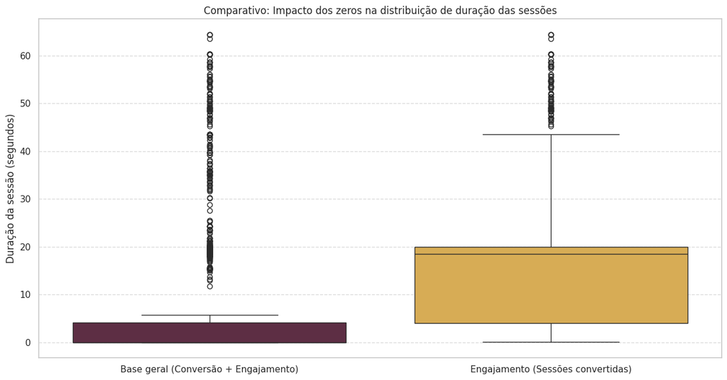

```python
# i. Preparando dados para plot comparativo
dados_com_zeros = dados_tratados.copy()
dados_com_zeros['categoria'] = 'Base geral (Conversão + Engajamento)'

dados_sem_zeros = dados_tratados[dados_tratados['session_duration'] > 0].copy()
dados_sem_zeros['categoria'] = 'Engajamento (Sessões convertidas)'

df_comparativo = pd.concat([dados_com_zeros, dados_sem_zeros])

# ii. Boxplot comparativo de duração das sessões (com e sem zeros)
plt.figure(figsize=(15, 7.5))
sns.boxplot(data=df_comparativo, x='categoria', y='session_duration', hue='categoria', palette=paleta, legend=False)

plt.title('Comparativo: Impacto dos zeros na distribuição de duração das sessões', fontsize=12)
plt.ylabel('Duração da sessão (segundos)', fontsize=12)
plt.xlabel('')

plt.grid(axis='y', linestyle='--', alpha=0.7)
plt.savefig(os.path.join(DIRETORIO_PLOTS, 'comparativo_distribuicao.png'), dpi=300, bbox_inches='tight')

plt.show()
```

> Esta segmentação é fundamental para evitar que o ruído técnico ou o comportamento atípico de navegação enviesem a avaliação da nova funcionalidade, garantindo que as métricas de performance reflitam com precisão a experiência dos usuários que efetivamente converteram em navegação.

### 3.2 Distribuição de dados

Nesta etapa, verifica-se a distribuição da variável `session_duration` nos grupos "A" e "B" utilizando o teste de normalidade de Shapiro-Wilk e análise de histogramas. O objetivo é determinar se a distribuição dos dados segue uma curva normal (Gaussiana), o que orientará a escolha dos testes de hipótese subsequentes.

Obs.: Será utilizado o dataset *dados_engajados*, que corresponde aos *dados_tratados* sem os zeros.

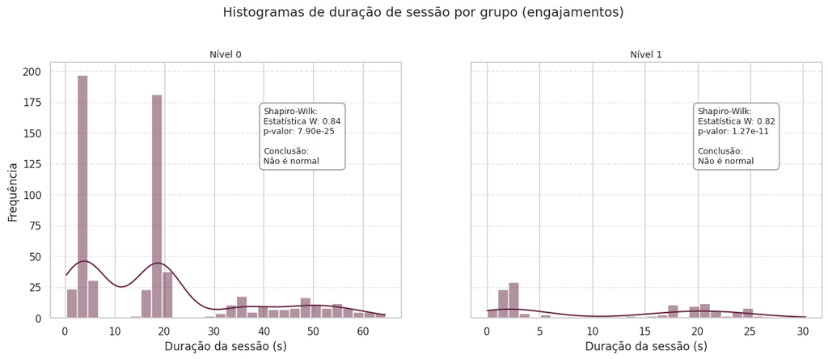

```python
# i. Segmentação para análise de engajamento (removendo sessões com duração zero)
dados_engajados = dados_tratados[dados_tratados['session_duration'] > 0].copy()

# ii. Histograma de duração de sessão por grupo com teste de normalidade Shapiro-Wilk

fig, axes = plt.subplots(1, 2, figsize=(15, 5), sharey=True)

grupos = sorted(dados_engajados['group'].unique())

posicoes = {'Nível 0': (40, 125), 'Nível 1': (20, 125)}

for i, grupo in enumerate(grupos):
    dados_nivel = dados_engajados[dados_engajados['group'] == grupo]['session_duration']

    # Executa o teste de Shapiro-Wilk
    stat, p_valor = shapiro(dados_nivel)

    # Histograma
    sns.histplot(data=dados_nivel, ax=axes[i], color='#652643', kde=True, bins=30)

    # Preparação do texto
    status = "Parece normal" if p_valor > 0.05 else "Não é normal"
    texto_resultado = f"Shapiro-Wilk:\nEstatística W: {stat:.2f}\np-valor: {p_valor:.2e}\n\nConclusão:\n{status}"

    # Posicionamento dinâmico
    x_pos, y_pos = posicoes[grupo]
    axes[i].text(x_pos, y_pos, texto_resultado, fontsize=9, bbox=dict(facecolor='white', alpha=0.9, edgecolor='gray', boxstyle='round,pad=0.5'))
    axes[i].set_title(f'{grupo}', fontsize=10)
    axes[i].set_xlabel('Duração da sessão (s)')
    axes[i].set_ylabel('Frequência' if i == 0 else '')
    axes[i].grid(axis='y', linestyle='--', alpha=0.5)

plt.suptitle('Histogramas de duração de sessão por grupo (engajamentos)', fontsize=14, y=1.05)

plt.savefig(os.path.join(DIRETORIO_PLOTS, 'histograma_normalidade.png'), dpi=300, bbox_inches='tight')
plt.show()
```

> A análise dos histogramas (acima) e os resultados do teste de Shapiro-Wilk confirmam a ausência de normalidade em ambos os grupos (*p*-valor < 0.05). Além disso, a visualização evidencia uma distribuição assimétrica, em que a maior parte dos usuários apresenta engajamentos curtos, enquanto uma cauda longa representa usuários de alta permanência.

> Dado o não cumprimento da premissa de normalidade, testes paramétricos, como o Teste-T, tornam-se tecnicamente inadequados. Portanto, o Teste U de Mann-Whitney será adotado para a análise de significância estatística.

### 3.3 Comparação de engajamento entre grupos

Este é um método não-paramétrico robusto que compara as distribuições e as medianas de duas amostras independentes. Sua principal vantagem nesse contexto é a resistência a outliers (valores extremos), garantindo que sessões longas não distorçam a avaliação geral entre os cenários/grupos.

```
Teste de Mann-Whitney U --------------------
Estatística U: 55084.00
p-valor:       3.41e-07
--------------------------------------------
***Rejeitamos a hipótese nula (H0)***
(HÁ uma diferença estatisticamente significativa entre os grupos).

--------------------------------------------

Resumo de engajamento por grupo:
Mediana Nível 0: 18.62 segundos
Mediana Nível 1: 12.99 segundos

Média* Nível 0: 18.83 segundos
Média* Nível 1: 11.46 segundos
* Apenas para conferência, sem significancia estatística.
--------------------------------------------
```

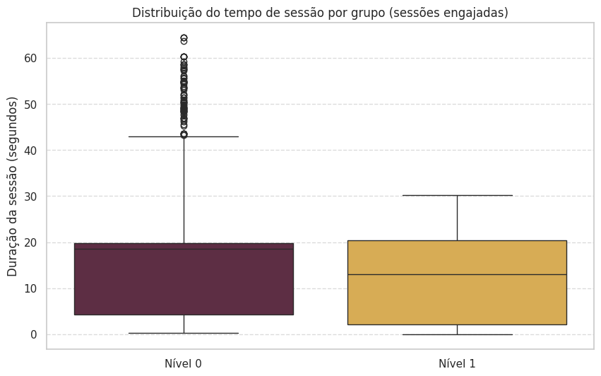

```python
# i. Isolando as amostras dos dois grupos na base de engajados
grupo_nivel_0 = dados_engajados[dados_engajados['group'] == 'Nível 0']['session_duration']
grupo_nivel_1 = dados_engajados[dados_engajados['group'] == 'Nível 1']['session_duration']


# ii. Executando o Teste de Mann-Whitney U (Bicaudal)
stat, p_valor = mannwhitneyu(grupo_nivel_0, grupo_nivel_1, alternative='two-sided')


# iii. Exibição dos resultados
print("Teste de Mann-Whitney U --------------------")
print(f"Estatística U: {stat:.2f}")
print(f"p-valor:       {p_valor:.2e}")
print("-" * 44)


# iv. Interpretação automática dos resultados
nivel_significancia = 0.05

if p_valor < nivel_significancia:
    print("***Rejeitamos a hipótese nula (H0)***\n(HÁ uma diferença estatisticamente significativa entre os grupos).\n")
else:
    print("***Não rejeitamos a hipótese nula (H0)***\n(NÃO há uma diferença estatisticamente significativa entre os grupos).\n")
print("-" * 44)


# v. Resumo de medianas de session_duration por grupo
print("\nResumo de engajamento por grupo:")
print(f"Mediana Nível 0: {grupo_nivel_0.median():.2f} segundos")
print(f"Mediana Nível 1: {grupo_nivel_1.median():.2f} segundos\n")


# vi. Resumo de médias de session_duration por grupo
print(f"Média* Nível 0: {grupo_nivel_0.mean():.2f} segundos")
print(f"Média* Nível 1: {grupo_nivel_1.mean():.2f} segundos")
print("* Apenas para conferência, sem significancia estatística.")
print("-" * 44)


# vii. Boxplot de duração de sessão por grupo (base engajada)
plt.figure(figsize=(10, 6))
sns.boxplot(data=dados_engajados, x='group', y='session_duration', hue='group', palette=paleta, legend=False)

plt.title('Distribuição do tempo de sessão por grupo (sessões engajadas)', fontsize=12)
plt.ylabel('Duração da sessão (segundos)', fontsize=12)
plt.xlabel('')
plt.grid(axis='y', linestyle='--', alpha=0.7)

plt.savefig(os.path.join(DIRETORIO_PLOTS, 'boxplot_engajamento.png'), dpi=300, bbox_inches='tight')
plt.show()
```

> O teste confirma que a diferença de engajamento entre os grupos é estatisticamente significativa (U = 55084, p < 0.001). Usuários do **Nível 0 permanecem mais tempo na página**, sendo a mediana de 18.6s contra 12.9s do Nível 1, uma diferença de aproximadamente **43%**.

> *O alinhamento entre mediana e média em ambos os grupos (18.6s e 18.8s no Nível 0; 13.0s e 11.5s no Nível 1) sugere que os outliers não estão distorcendo a tendência central observada.*

> A representação gráfica (boxplot) evidencia outliers no quartil superior do Nível 0, representando usuários de alta permanência ausentes no Nível 1.

> *Esses valores reforçam o baixo engajamento do Nível 1.*

### 3.4 Comparação de conversão entre grupos

Nesta etapa, verifica-se se a diferença nas taxas de conversão entre os grupos é estatisticamente significativa. Como `converted` é uma variável categórica binária, o teste Qui-Quadrado de independência é o método adequado para avaliar se a distribuição de conversões varia entre os grupos ou se é resultado do acaso.

```
Teste Qui-Quadrado --------------------------
Estatística χ²: 173.73
Graus de liberdade: 1
p-valor:        1.13e-39
--------------------------------------------
***Rejeitamos a hipótese nula (H0)***
(HÁ uma diferença estatisticamente significativa nas taxas de conversão entre os grupos).

--------------------------------------------
```

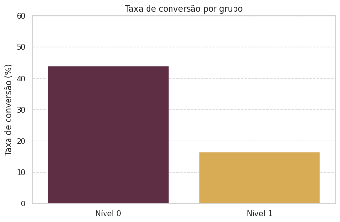

```python
# i. Construindo a tabela de contingência entre grupo e conversão
tabela = pd.crosstab(dados_tratados['group'], dados_tratados['converted'])

# ii. Executando o Teste Qui-Quadrado
chi2, p_valor, dof, expected = chi2_contingency(tabela)

# iii. Exibição dos resultados
print("Teste Qui-Quadrado --------------------------")
print(f"Estatística χ²: {chi2:.2f}")
print(f"Graus de liberdade: {dof}")
print(f"p-valor:        {p_valor:.2e}")
print("-" * 44)

# iv. Interpretação automática dos resultados
if p_valor < ALPHA:
    print("***Rejeitamos a hipótese nula (H0)***\n(HÁ uma diferença estatisticamente significativa nas taxas de conversão entre os grupos).\n")
else:
    print("***Não rejeitamos a hipótese nula (H0)***\n(NÃO há uma diferença estatisticamente significativa nas taxas de conversão entre os grupos).\n")
print("-" * 44)

# iv. Calculando a taxa de conversão por grupo
taxa_conversao = dados_tratados.groupby('group')['converted'].mean() * 100

# v. Barplot de taxa de conversão por grupo
plt.figure(figsize=(8, 5))
sns.barplot(x=taxa_conversao.index, y=taxa_conversao.values, hue=taxa_conversao.index, palette=paleta, legend=False)

plt.title('Taxa de conversão por grupo', fontsize=12)
plt.ylabel('Taxa de conversão (%)', fontsize=12)
plt.xlabel('')
plt.ylim(0, 60)
plt.grid(axis='y', linestyle='--', alpha=0.7)

plt.savefig(os.path.join(DIRETORIO_PLOTS, 'barplot_conversao.png'), dpi=300, bbox_inches='tight')
plt.show()
```

> O teste confirma que a diferença nas taxas de conversão entre os grupos é estatisticamente significativa (χ² = 173.73, gl = 1, p < 0.001).

> Com uma taxa de **43,94%** no **Nível 0** contra **16,52%** no **Nível 1**, o acesso direto à página converte mais do que o dobro em relação ao acesso via aba geral.

## 4. Análise exploratória de dados

Nesta seção, explora-se o comportamento dos usuários nos dois grupos do experimento a partir das principais métricas de produto: volume de acessos, tempo de sessão, taxa de conversão e distribuição temporal. O objetivo é traduzir os dados tratados em evidências que orientem decisões sobre a configuração do menu lateral.

### 4.1 Volume de acessos

Abaixo, verifica-se o volume total de acessos registrado em cada grupo do experimento, considerando tanto sessões únicas quanto acessos recorrentes do mesmo usuário.

```python
# i. Contagem de acessos por grupo
acessos_por_grupo = dados_tratados['group'].value_counts()
print("Contagem de acessos por grupo: -------------")
print(acessos_por_grupo.to_string())
print("-" * 44)

# ii. Usuários únicos e recorrência média por grupo
usuarios_unicos = dados_tratados.groupby('group')['user_id'].nunique()
total_acessos = dados_tratados.groupby('group').size()
recorrencia_media = (total_acessos / usuarios_unicos).round(2)

print("Usuários únicos por grupo:")
print(usuarios_unicos.to_string())
print("-" * 44)
print("Recorrência média por grupo (acessos/usuário):")
print(recorrencia_media.to_string())
print("-" * 44)
```

```
Contagem de acessos por grupo: -------------
group
Nível 0    1452
Nível 1     817
--------------------------------------------
Usuários únicos por grupo:
group
Nível 0    984
Nível 1    634
--------------------------------------------
Recorrência média por grupo (acessos/usuário):
group
Nível 0    1.48
Nível 1    1.29
--------------------------------------------
```

> O **Nível 0** registrou maior volume de tráfego, com **1.452 acessos** contra **817 do Nível 1**, uma diferença de aproximadamente **78%**.

> *Essa assimetria pode refletir tanto uma preferência genuína dos usuários pelo acesso direto quanto um desequilíbrio na distribuição do tráfego durante a coleta, o que reforça a importância de avaliar as métricas de conversão e engajamento de forma complementar.*

> Ao desconsiderar os acessos repetidos, o **Nível 0** contabiliza **984 usuários únicos** contra **634 do Nível 1**.

> *Além disso, usuários do Nível 0 retornam em média **1,48 vezes** à página, contra **1,29 do Nível 1**, indicando que o acesso direto além de atrair mais usuários, também faz os mesmos acessarem com maior frequência.*

### 4.2 Tendência temporal

Abaixo, analisa-se o comportamento dos grupos ao longo do dia, observando a evolução do número total de acessos e a taxa de conversão por hora.

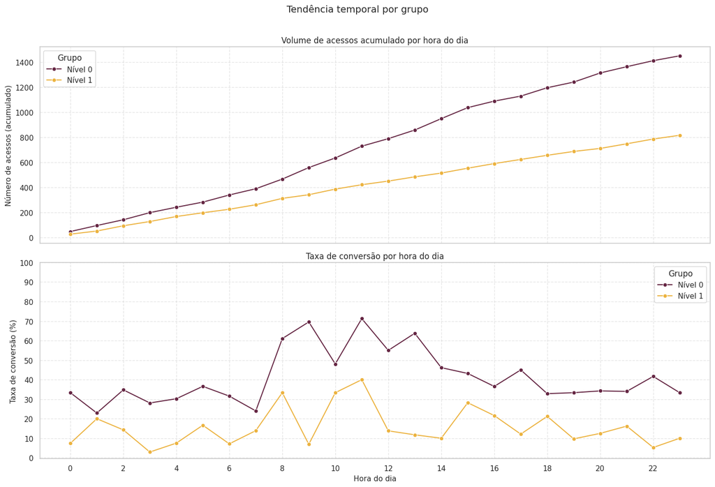

```python
# i. Extraindo a hora do timestamp
dados_tratados['hora'] = pd.to_datetime(dados_tratados['timestamp']).dt.hour

# ii. Agregando volume de acessos e taxa de conversão por hora e grupo
acessos_hora = dados_tratados.groupby(['hora', 'group']).size().reset_index(name='acessos')
acessos_hora['acessos_acumulados'] = acessos_hora.groupby('group')['acessos'].cumsum()
conversao_hora = dados_tratados.groupby(['hora', 'group'])['converted'].mean().reset_index()
conversao_hora['converted'] = conversao_hora['converted'] * 100

# iii. Plot duplo
fig, axes = plt.subplots(2, 1, figsize=(15, 10), sharex=True)

# Volume de acessos
sns.lineplot(data=acessos_hora, x='hora', y='acessos_acumulados', hue='group', palette=paleta, marker='o', ax=axes[0])
axes[0].set_title('Volume de acessos acumulado por hora do dia', fontsize=12)
axes[0].set_ylabel('Número de acessos (acumulado)', fontsize=11)
axes[0].set_xticks(range(0, 24, 2))
axes[0].xaxis.set_minor_locator(plt.MultipleLocator(1))
axes[0].set_yticks(range(0, 1600, 200))
axes[0].yaxis.set_minor_locator(plt.MultipleLocator(5))
axes[0].grid(True, which='major', linestyle='--', alpha=0.5)
axes[0].tick_params(which='minor', length=3)
axes[0].tick_params(which='major', length=6)
axes[0].legend(title='Grupo')

# Taxa de conversão
sns.lineplot(data=conversao_hora, x='hora', y='converted', hue='group', palette=paleta, marker='o', ax=axes[1])
axes[1].set_title('Taxa de conversão por hora do dia', fontsize=12)
axes[1].set_ylabel('Taxa de conversão (%)', fontsize=11)
axes[1].set_xlabel('Hora do dia', fontsize=11)
axes[1].set_xticks(range(0, 24, 2))
axes[1].xaxis.set_minor_locator(plt.MultipleLocator(1))
axes[1].set_yticks(range(0, 110, 10))
axes[1].yaxis.set_minor_locator(plt.MultipleLocator(5))
axes[1].grid(True, which='major', linestyle='--', alpha=0.5)
axes[1].tick_params(which='minor', length=3)
axes[1].tick_params(which='major', length=6)
axes[1].legend(title='Grupo')

plt.suptitle('Tendência temporal por grupo', fontsize=14, y=1.01)
plt.tight_layout()

plt.savefig(os.path.join(DIRETORIO_PLOTS, 'tendencia_temporal.png'), dpi=300, bbox_inches='tight')
plt.show()
```

> O volume de acessos acumulado evidencia que o Nível 0 sustenta uma vantagem consistente ao longo de todo o dia, encerrando o período com 1.452 acessos contra 817 do Nível 1.

> *A diferença observada se estabelece desde as primeiras horas e se mantém estável até o fim do dia, sem reversões de tendência.*

> O Nível 1 apresenta comportamento mais volátil e sem padrão claro, com conversões que oscilam entre menos de 10% e 40% (dependendo da hora).

> *Tal comportamento indica menor previsibilidade de resultado independente do horário de acesso.*

### 4.3 Conversão por dispositivo

Abaixo, analisa-se a taxa de conversão por dispositivo em cada grupo, buscando identificar se o tipo de acesso influencia a eficácia das configurações do menu lateral.

```python
# i. Taxa de conversão por dispositivo e grupo
conv_device = dados_tratados.groupby(['device', 'group'])['converted'].mean() * 100
print("Taxa de conversão por dispositivo e grupo:")
print("-" * 44)
print(conv_device.round(2).astype(str).add('%').to_string())
print("-" * 44)

# ii. Razão de conversão Nível 0 / Nível 1 por dispositivo
pivot_device = conv_device.unstack()
pivot_device['razao'] = (pivot_device['Nível 0'] / pivot_device['Nível 1']).round(2)
print("\nRazão de conversão (Nível 0 / Nível 1) por dispositivo:")
print("-" * 44)
print(pivot_device['razao'].to_string())
print("-" * 44)
```

```
Taxa de conversão por dispositivo e grupo:
--------------------------------------------
device      group
Desktop     Nível 0    42.95%
            Nível 1    14.85%
Smartphone  Nível 0    46.12%
            Nível 1     20.0%
Tablet      Nível 0     42.8%
            Nível 1    15.15%
--------------------------------------------

Razão de conversão (Nível 0 / Nível 1) por dispositivo:
--------------------------------------------
device
Desktop       2.89
Smartphone    2.31
Tablet        2.82
--------------------------------------------
```

> A vantagem do Nível 0 se mantém de forma consistente independente do dispositivo de acesso com taxas de conversão entre 42,8% e 46,1% contra 14,9% e 20,0% do Nível 1 em desktop, smartphone e tablet.

> *A razão entre os grupos apresenta pouca variação, e o menor valor de 2.31x em Smartphones pode indicar que o acesso via aba geral (Nível 1) pode ter leve vantagem sobre os demais dispositivos (sem força estatística);*

> *O resultado indica que a superioridade do acesso direto é estrutural à configuração do menu, não influenciada pelo contexto ou dispositivo do usuário.*

### 4.4 Conversão por país

Abaixo, analisa-se a taxa de conversão por país em cada grupo, buscando identificar padrões geográficos no comportamento dos usuários.

```python
# i. Taxa de conversão por país e grupo
conv_country = dados_tratados.groupby(['country', 'group'])['converted'].mean() * 100
print("Taxa de conversão por país e grupo:")
print("-" * 44)
print(conv_country.round(2).astype(str).add('%').to_string())
print("-" * 44)
```

```
Taxa de conversão por país e grupo:
--------------------------------------------
country      group
Alemanha     Nível 0     44.0%
             Nível 1     13.0%
Austrália    Nível 0     46.3%
             Nível 1     13.4%
Brasil       Nível 0     37.7%
             Nível 1    18.64%
Canadá       Nível 0    48.81%
             Nível 1    17.27%
EUA          Nível 0    49.19%
             Nível 1    12.94%
França       Nível 0    38.95%
             Nível 1    15.85%
Reino Unido  Nível 0    41.36%
             Nível 1    22.39%
Índia        Nível 0    45.45%
             Nível 1    15.38%
--------------------------------------------
```

```python
# ii. Razão de conversão Nível 0 / Nível 1 por país
pivot_country = conv_country.unstack()
pivot_country['razao'] = (pivot_country['Nível 0'] / pivot_country['Nível 1']).round(2)
print("\nRazão de conversão (Nível 0 / Nível 1) por país:")
print("-" * 44)
print(pivot_country['razao'].to_string())
print("-" * 44)
```

```
Razão de conversão (Nível 0 / Nível 1) por país:
--------------------------------------------
country
Alemanha       3.38
Austrália      3.45
Brasil         2.02
Canadá         2.83
EUA            3.80
França         2.46
Reino Unido    1.85
Índia          2.95
--------------------------------------------
```

> A vantagem do **Nível 0 se mantém em todos os países analisados**, mas com intensidade variável.

> *EUA e Austrália apresentam as maiores razões de conversão (3,80x e 3,45x respectivamente), indicando que o acesso direto é especialmente eficaz nesses mercados. Em contraste, Reino Unido e Brasil apresentam as menores razões (1,85x e 2,02x), ainda favoráveis ao Nível 0, mas sugerindo que nesses mercados o acesso via aba geral tem desempenho relativamente menos prejudicado.*

> **Investigar as particularidades de navegação nesses países pode revelar oportunidades de otimização localizada da interface.**

## 5. Conclusões e recomendações

**1 ) Qual configuração do menu lateral levou mais usuários a acessarem a página específica?**

> O **Nível 0** registrou maior volume de tráfego, com **1.452 acessos** contra **817 do Nível 1**, uma diferença de **78%**. Corrigindo pela recorrência, o Nível 0 também lidera em usuários únicos (**984 vs 634**), com recorrência média superior (**1,48 vs 1,29 acessos/usuário**).

**2 ) Qual o tempo médio de sessão para cada configuração do menu?**

> Considerando apenas sessões com engajamento efetivo (duração > 0), o **Nível 0** apresenta média de **18,83s** contra **11,46s do Nível 1**. A mediana (métrica mais confiável dado o afastamento da normalidade) confirma a mesma tendência: **18,62s vs 12,99s**, uma diferença de aproximadamente **43%**.

**3 ) Qual é a taxa de conversão para cada configuração do menu?**

> A taxa de conversão do **Nível 0** foi de **43,94%**, contra **16,52% do Nível 1**, o acesso direto converte **2,7x mais** que o acesso via aba geral.

**4 ) A diferença nos acessos entre as configurações é estatisticamente significativa?**

> Sim. O teste Qui-Quadrado confirmou diferença estatisticamente significativa nas taxas de conversão entre os grupos (χ² = 173,73, gl = 1, p < 0,001). O teste U de Mann-Whitney confirmou o mesmo para o engajamento (U = 55.084, p < 0,001). Ambos os resultados rejeitam a hipótese nula com alto grau de confiança.

**5 ) Quais insights podem ser derivados dos dados para otimizar a navegação do site e aumentar o engajamento dos usuários?**

> - O acesso direto à página (Nível 0) supera o acesso via aba geral em todas as dimensões analisadas (volume, engajamento e conversão) de forma consistente entre dispositivos e mercados geográficos, indicando que a vantagem é estrutural à configuração do menu, não contextual;
> - A concentração de conversões no intervalo **9h–11h** sugere que ações de ativação ou comunicação direcionada nesse período podem amplificar o engajamento existente;
> - A menor razão de conversão entre grupos no **Reino Unido** (1,85x) e **Brasil** (2,02x) indica que nesses mercados o Nível 1 performa relativamente melhor, o que pode justificar investigação localizada antes de um rollout global definitivo;
> - A presença de usuários recorrentes no **Nível 0** (recorrência 1,48x) sugere que o acesso direto não apenas converte mais na primeira visita, mas também faz os usuários retornarem, um indicador positivo de relevância percebida da página.

**7 ) Quais recomendações você faria com base nos dados analisados para otimizar a navegação do site?**

> - **Adotar o Nível 0 como configuração padrão** do menu lateral, dado o desempenho superior em todas as métricas e a confirmação estatística da diferença entre os grupos;
> - **Investigar o comportamento nos mercados de Reino Unido e Brasil** antes de um rollout definitivo, dado o menor diferencial de conversão observado nesses países;
> - **Explorar estratégias de ativação no período 9h–11h**, onde o Nível 0 atinge seus maiores índices de conversão, como notificações, campanhas ou destaques na interface;
> - **Monitorar a recorrência de acessos** como métrica complementar de engajamento em experimentos futuros, usuários que retornam à mesma página são um sinal de intenção que a taxa de conversão isolada não captura.